# Short protocol for exploratory amino acid and fat mass analyses

Thomas Olsen (PhD), Ane S. Kværner (PhD), Vegard Lysne (PhD), Kathrine J. Vinknes (PhD)

### Aim of the study

The aim of the present project is to explore the relationship between clinical markers of body composition derived from bioelectrical impedance analysis (BIA) and dual X-ray absorptiometry (DXA) and amino acid profile in plasma and urine. Protein intake and plasma concentrations of amino acids are becoming increasingly recognized in metabolic disease. Branched chain amino acids (BCAAs) have recently been considered causal in the development of type 2 diabetes, and the literature on the associations of aromatic amino acids and sulfur amino acids with obesity is extensively documented in animal and observational studies. Less literature is available on the relationship between amino acids and body fat distribution and novel, clinically relevant markers of body composition. In this cross-sectional study we will use data from normal weight and overweight subjects to assess the relationship between distribution of fat mass derived from DXA and BIA including visceral adipose tissue (VAT), subcutaneous adipose tissue (SAT) and appendicular adipose tissue with plasma and urine concentrations of amino acids. In addition, we will use raw impedance data in the clinical assessments of body composition including resistance, reactance and phase angle data from the bioimpedance measurements and assess their relationship with the amino acid profile in blood and urine.

#### Initial analyses

All statistical analyses in this study will be conducted by using R software for statistical computing. Distribution of continuous variables will be assessed visually, preferably by using the `skimr::skim()` function, but depend on the methods used for outcome analysis. E.g. for regression analyses, normal distribution will be checked for model residuals and transformations applied as appropriate. Measures of central tendency and dispersion will be presented in a **Table 1** for relevant variables and the full amino acid profile for the total population.

#### Main outcome analyses

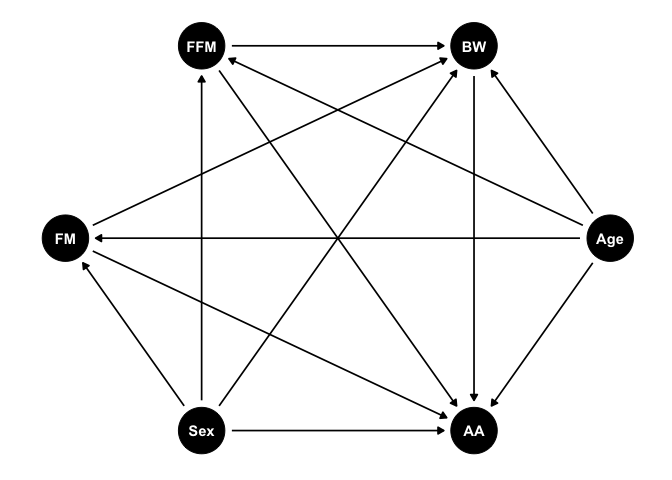

```r
dag<-dagitty::dagitty("dag{FM -> AA
FFM -> AA
Age -> AA
Age -> FFM
Sex -> FM
Sex -> FFM
FM -> BW
FFM -> BW
Sex -> BW
BW -> AA
Sex -> AA
Age -> FM
Age -> BW
FM [exposure]
AA [outcome]}")

tidy_dag<-ggdag::tidy_dagitty(dag)

ggdag::ggdag(dag, layout="circle") +
  ggthemes::theme_tufte() +
  theme(axis.text = element_blank(),
        axis.title = element_blank(),
        axis.ticks = element_blank())
```

**Figure 1:** *Directed acyclic graph illustrating relevant associations between the exposure- and outcome variable and potential confounding factors. Abbreviations: AA, amino acid; BW, body weight; FFM, fat free mass; FM, fat mass.*

Based on the DAG above, minimal adjustment sets were created. Models will be adjusted for age, sex and fat free mass. Note that fat mass is a proxy for body fat distribution.

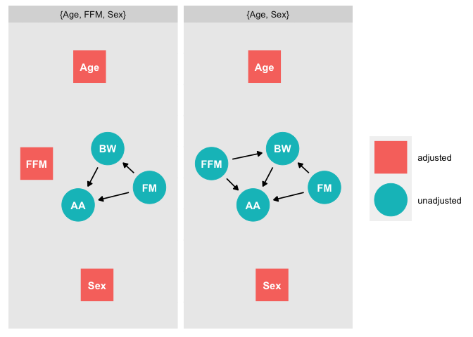

```r
ggdag_adjustment_set(tidy_dag, type="all", effect="total") +
  theme_dag_grey() +
  theme(legend.title=element_blank())
```

**Figure 2**: *Valid minimal adjustment sets based on the directed acyclic graph. Abbreviations: AA, amino acid; BW, body weight; FFM, fat free mass; FM, fat mass.*

### Presentation of results

Whenever possible, results will be presented visually using the `ggplot2()` package. Scatter plots with the linear regression line superimposed. Hypothetical outcome plots, based on 50 bootstrapped samples, are included to visualize the uncertainty around the estimates. An example is shown below. In the online supplement we will include plot of the real data and 19 null plots to illustrate expected variation under conditions with no association.

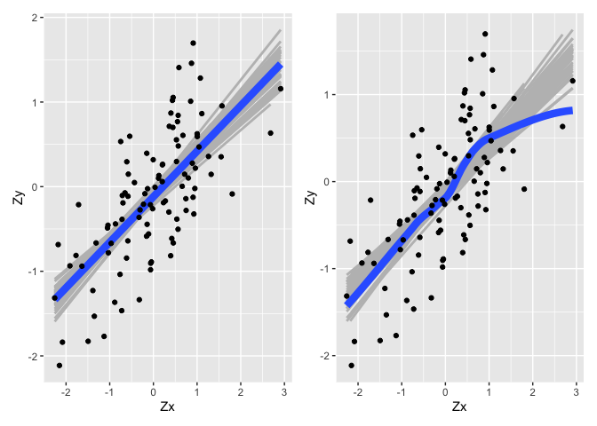

```r
x <- rnorm(100, 10, 1.5)
Zx <- scale(x)
Zy <- .5*Zx + rnorm(100, 0, sqrt(1 - (.8^2)))
df <- data.frame(Zx, Zy)

a<-ggplot(df, aes(Zx, Zy)) +
  geom_smooth(data=bootstrapper(50), aes(group=.draw), color="grey", se=F, method="lm") +
  geom_smooth(method="lm", se=F, size=3) +
  geom_point()

b<-ggplot(df, aes(Zx, Zy)) +
  geom_smooth(data=bootstrapper(50), aes(group=.draw), color="grey", se=F, method="lm") +
  geom_smooth(method="loess", se=F, size=3) +
  geom_point()

a+b
```

**Figure 3**: *Example of an hypothetical outcome plot with 50 bootstrapped samples of simulated data. Blue line indicates original line of best fit, grey lines are derived from 50 bootstrapped samples. Panels show linear and loess fit*

#### Statistical software

All statistical analyses will be performed using the most recent R version. Data cleaning and organization will be performed using packages available in the `tidyverse()` collection of packages. All code and affiliated data will be made available on GitHub upon publication of the manuscript.